# Explore_bikeshare_data

### Explore Bike Share Data

For this project, your goal is to ask and answer three questions about the available bikeshare data from Washington, Chicago, and New York. This notebook can be submitted directly through the workspace when you are confident in your results.

You will be graded against the project [Rubric](https://review.udacity.com/#!/rubrics/2508/view) by a mentor after you have submitted. To get you started, you can use the template below, but feel free to be creative in your solutions!

```r
# Check current working directory
print(getwd())
```

```
[1] "/workspace/home"
```

```r
ny <- read.csv("new-york-city.csv")
wash <- read.csv("washington.csv")
chi <- read.csv("chicago.csv")
```

[output not shown]

```r
head(ny)
```

A data.frame: 6 x 9

|  | X <int> | Start.Time <chr> | End.Time <chr> | Trip.Duration <int> | Start.Station <chr> | End.Station <chr> | User.Type <chr> | Gender <chr> | Birth.Year <dbl> |
| --- | --- | --- | --- | --- | --- | --- | --- | --- | --- |
| 1 | 5688089 | 2017-06-11 14:55:05 | 2017-06-11 15:08:21 | 795 | Suffolk St & Stanton St | W Broadway & Spring St | Subscriber | Male | 1998 |
| 2 | 4096714 | 2017-05-11 15:30:11 | 2017-05-11 15:41:43 | 692 | Lexington Ave & E 63 St | 1 Ave & E 78 St | Subscriber | Male | 1981 |
| 3 | 2173887 | 2017-03-29 13:26:26 | 2017-03-29 13:48:31 | 1325 | 1 Pl & Clinton St | Henry St & Degraw St | Subscriber | Male | 1987 |
| 4 | 3945638 | 2017-05-08 19:47:18 | 2017-05-08 19:59:01 | 703 | Barrow St & Hudson St | W 20 St & 8 Ave | Subscriber | Female | 1986 |
| 5 | 6208972 | 2017-06-21 07:49:16 | 2017-06-21 07:54:46 | 329 | 1 Ave & E 44 St | E 53 St & 3 Ave | Subscriber | Male | 1992 |
| 6 | 1285652 | 2017-02-22 18:55:24 | 2017-02-22 19:12:03 | 998 | State St & Smith St | Bond St & Fulton St | Subscriber | Male | 1986 |

```r
head(wash)
```

A data.frame: 6 x 7

|  | X <int> | Start.Time <chr> | End.Time <chr> | Trip.Duration <dbl> | Start.Station <chr> | End.Station <chr> | User.Type <chr> |
| --- | --- | --- | --- | --- | --- | --- | --- |
| 1 | 1621326 | 2017-06-21 08:36:34 | 2017-06-21 08:44:43 | 489.066 | 14th & Belmont St NW | 15th & K St NW | Subscriber |
| 2 | 482740 | 2017-03-11 10:40:00 | 2017-03-11 10:46:00 | 402.549 | Yuma St & Tenley Circle NW | Connecticut Ave & Yuma St NW | Subscriber |
| 3 | 1330037 | 2017-05-30 01:02:59 | 2017-05-30 01:13:37 | 637.251 | 17th St & Massachusetts Ave NW | 5th & K St NW | Subscriber |
| 4 | 665458 | 2017-04-02 07:48:35 | 2017-04-02 08:19:03 | 1827.341 | Constitution Ave & 2nd St NW/DOL | M St & Pennsylvania Ave NW | Customer |
| 5 | 1481135 | 2017-06-10 08:36:28 | 2017-06-10 09:02:17 | 1549.427 | Henry Bacon Dr & Lincoln Memorial Circle NW | Maine Ave & 7th St SW | Subscriber |
| 6 | 1148202 | 2017-05-14 07:18:18 | 2017-05-14 07:24:56 | 398.000 | 1st & K St SE | Eastern Market Metro / Pennsylvania Ave & 7th St SE | Subscriber |

```r
head(chi)
```

A data.frame: 6 x 9

|  | X <int> | Start.Time <chr> | End.Time <chr> | Trip.Duration <int> | Start.Station <chr> | End.Station <chr> | User.Type <chr> | Gender <chr> | Birth.Year <dbl> |
| --- | --- | --- | --- | --- | --- | --- | --- | --- | --- |
| 1 | 1423854 | 2017-06-23 15:09:32 | 2017-06-23 15:14:53 | 321 | Wood St & Hubbard St | Damen Ave & Chicago Ave | Subscriber | Male | 1992 |
| 2 | 955915 | 2017-05-25 18:19:03 | 2017-05-25 18:45:53 | 1610 | Theater on the Lake | Sheffield Ave & Waveland Ave | Subscriber | Female | 1992 |
| 3 | 9031 | 2017-01-04 08:27:49 | 2017-01-04 08:34:45 | 416 | May St & Taylor St | Wood St & Taylor St | Subscriber | Male | 1981 |
| 4 | 304487 | 2017-03-06 13:49:38 | 2017-03-06 13:55:28 | 350 | Christiana Ave & Lawrence Ave | St. Louis Ave & Balmoral Ave | Subscriber | Male | 1986 |
| 5 | 45207 | 2017-01-17 14:53:07 | 2017-01-17 15:02:01 | 534 | Clark St & Randolph St | Desplaines St & Jackson Blvd | Subscriber | Male | 1975 |
| 6 | 1473887 | 2017-06-26 09:01:20 | 2017-06-26 09:11:06 | 586 | Clinton St & Washington Blvd | Canal St & Taylor St | Subscriber | Male | 1990 |

```r
#########################################
# Bikeshare Data Analysis Project in R  #
#       (Chicago, New York, Washington) #
#########################################

# Install required packages
install.packages("ggplot2")
install.packages("dplyr")
install.packages("lubridate")
```

```r
# Load required packages
library(ggplot2)   # For enhanced plots
library(dplyr)     # For data manipulation
library(lubridate) # For date/time operations

#----------------------------------------
# Helper Function: Load Data
#----------------------------------------
load_data <- function(city) {
  # Build the file name based on the city name (e.g., "chicago.csv")
  file_name <- paste0(city, ".csv")
  # Read the CSV file; note stringsAsFactors = FALSE avoids unwanted factor conversion
  data <- read.csv(file_name, stringsAsFactors = FALSE)

  # Convert the Start Time and End Time columns into date/time objects
  # Adjust the format if needed (here we assume "YYYY-MM-DD HH:MM:SS")
  data$Start.Time <- as.POSIXct(data$Start.Time, format="%Y-%m-%d %H:%M:%S")
  data$End.Time   <- as.POSIXct(data$End.Time, format="%Y-%m-%d %H:%M:%S")

  return(data)
}
```

### Question 1

**Your question 1 goes here.**

What are the most popular times of travel?

```r
# Your solution code goes here
#----------------------------------------
# Analysis Function: Popular Times of Travel
#----------------------------------------
popular_times <- function(data) {
  # Create new columns for month, day of week, and hour from the start time
  data <- data %>%
    mutate(month = month(Start.Time, label = TRUE, abbr = FALSE),
           day   = wday(Start.Time, label = TRUE, abbr = FALSE),
           hour  = hour(Start.Time))

  # Create frequency tables
  month_count <- table(data$month)
  day_count   <- table(data$day)
  hour_count  <- table(data$hour)

  # Find the most common month, day, and hour
  popular_month <- names(which.max(month_count))
  popular_day   <- names(which.max(day_count))
  popular_hour  <- names(which.max(hour_count))

  cat("Most common month: ", popular_month, "\n")
  cat("Most common day:   ", popular_day, "\n")
  cat("Most common start hour: ", popular_hour, "\n")

  # ----------------------------
  # Plotting the popular times:
  # ----------------------------

  # Base R plots
  par(mfrow=c(1,3))  # Set up a 1x3 grid of plots

  barplot(month_count,
          main = "Trips by Month",
          xlab = "Month",
          ylab = "Number of Trips",
          col  = "skyblue",
          las  = 2)

  barplot(day_count,
          main = "Trips by Day of Week",
          xlab = "Day",
          ylab = "Number of Trips",
          col  = "salmon",
          las  = 2)

  barplot(hour_count,
          main = "Trips by Start Hour",
          xlab = "Hour of Day",
          ylab = "Number of Trips",
          col  = "lightgreen")

  par(mfrow=c(1,1))  # Reset plot layout
}
```

```
============================================
Analysis for: CHICAGO
============================================

--- Popular Times of Travel ---
Most common month:  June
Most common day:    Tuesday
Most common start hour:  17

============================================
Analysis for: NEW-YORK-CITY
============================================

--- Popular Times of Travel ---
Most common month:  June
Most common day:    Wednesday
Most common start hour:  17
```

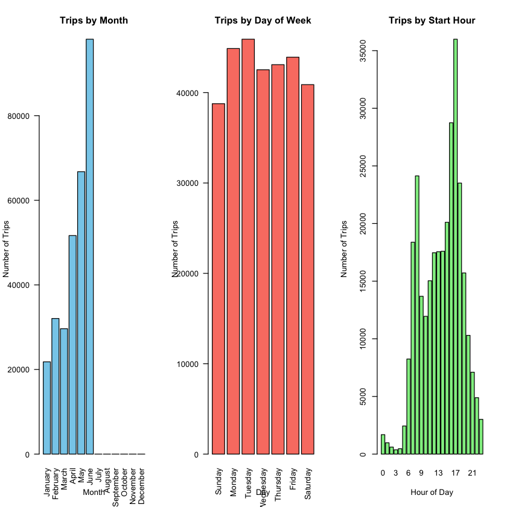

```
============================================
Analysis for: WASHINGTON
============================================

--- Popular Times of Travel ---
Most common month:  June
Most common day:    Wednesday
Most common start hour:  8
```

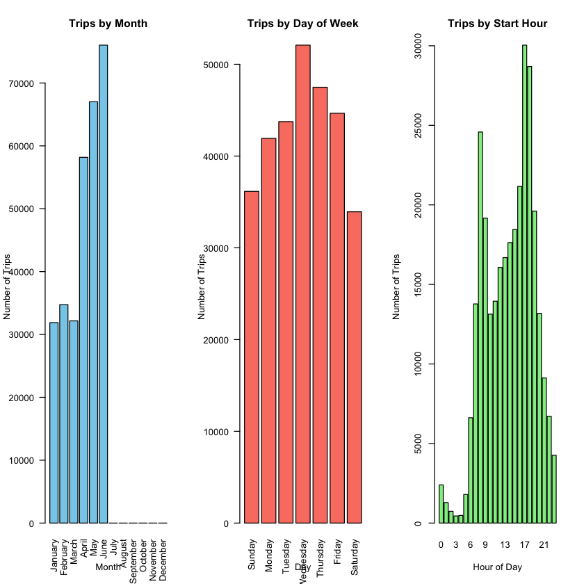

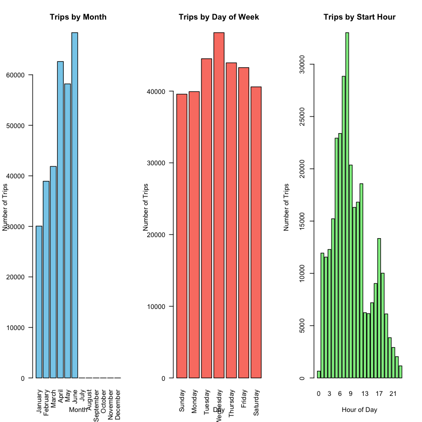

```r
#----------------------------------------
# Main Script: Loop Over Cities
#----------------------------------------
# List of cities to analyze (make sure the corresponding CSV files are in your working directory)
cities <- c("chicago", "new-york-city", "washington")

for (city in cities) {
  cat("\n============================================\n")
  cat("Analysis for:", toupper(city), "\n")
  cat("============================================\n")

  # Load the city data
  data <- load_data(city)

  #----------------------------------------
  # Explore Popular Times of Travel
  #----------------------------------------
  cat("\n--- Popular Times of Travel ---\n")
  popular_times(data)
}
```

**Summary of your question 1 results goes here.**

Chicago and New York had same start time, which shows interesting commuting dynamic for end of workday commuters returning home.

Washington showing a morning start time may indicate that commuters with better access to public transit will choose that over bikeshare.

### Question 2

**Your question 2 goes here.**

What are some of the most popular stations and trips?

```r
# Your solution code goes here
#----------------------------------------
# Analysis Function: Popular Stations and Trips
#----------------------------------------
popular_stations <- function(data) {
  # Compute frequency tables for start and end stations
  start_station_count <- table(data$Start.Station)
  end_station_count   <- table(data$End.Station)

  # Identify the most common start and end stations
  popular_start_station <- names(which.max(start_station_count))
  popular_end_station   <- names(which.max(end_station_count))

  # Create a combined trip column (e.g., "Station A to Station B")
  data$trip <- paste(data$Start.Station, "to", data$End.Station)
  trip_count <- table(data$trip)
  popular_trip <- names(which.max(trip_count))

  cat("Most common start station: ", popular_start_station, "\n")
  cat("Most common end station:   ", popular_end_station, "\n")
  cat("Most common trip:          ", popular_trip, "\n")

  # Plot the top 10 most common trips
  top10_trips <- sort(trip_count, decreasing = TRUE)[1:10]
  barplot(top10_trips,
          main = "Top 10 Most Common Trips",
          xlab = "Trip (Start to End)",
          ylab = "Count",
          col  = "purple",
          las  = 2)  # Rotate x-axis labels for readability
}
```

```
============================================
Analysis for: CHICAGO
============================================

--- Popular Stations and Trips ---
Most common start station:  Streeter Dr & Grand Ave
Most common end station:    Streeter Dr & Grand Ave
Most common trip:           Lake Shore Dr & Monroe St to Streeter Dr & Grand Ave

============================================
Analysis for: NEW-YORK-CITY
============================================

--- Popular Stations and Trips ---
Most common start station:  Pershing Square North
Most common end station:    Pershing Square North
Most common trip:           E 7 St & Avenue A to Cooper Square & E 7 St
```

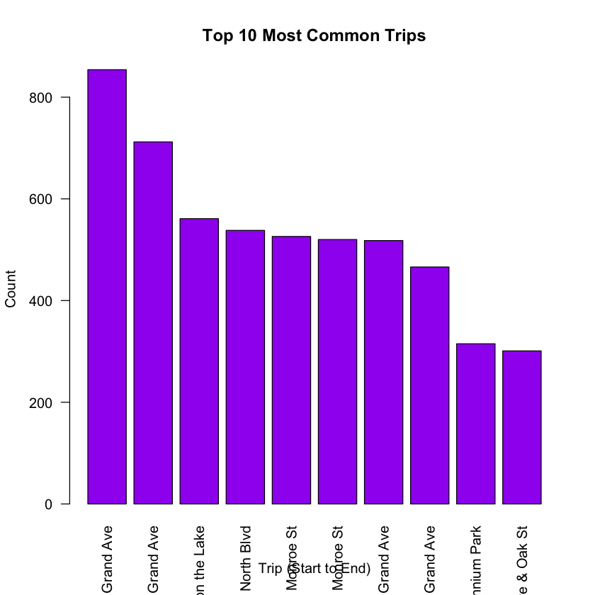

```
============================================
Analysis for: WASHINGTON
============================================

--- Popular Stations and Trips ---
Most common start station:  Columbus Circle / Union Station
Most common end station:    Columbus Circle / Union Station
Most common trip:           Jefferson Dr & 14th St SW to Jefferson Dr & 14th St SW
```

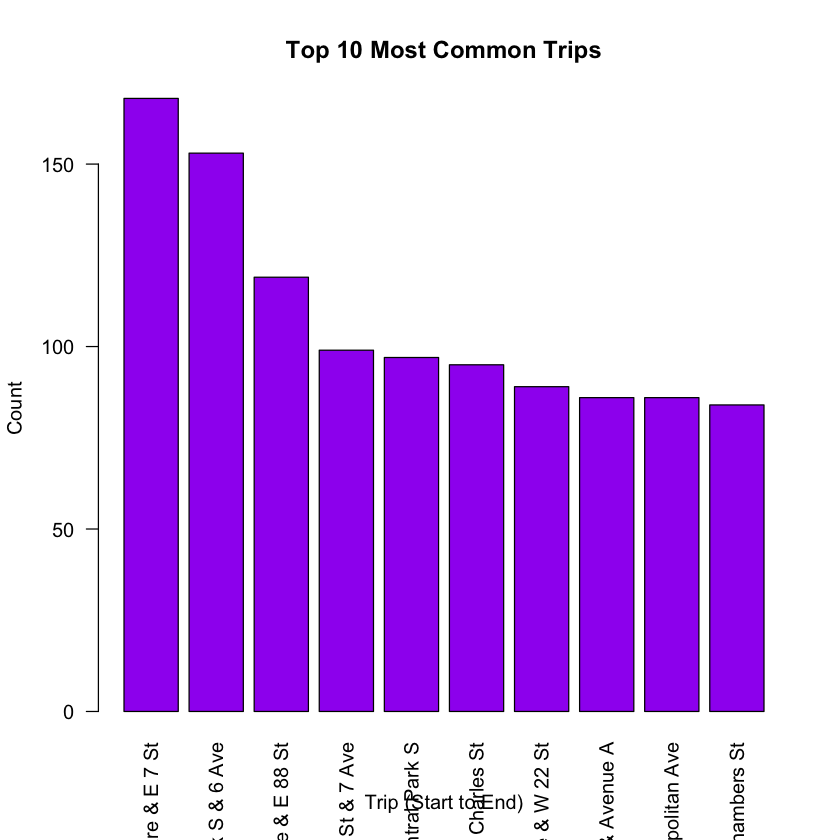

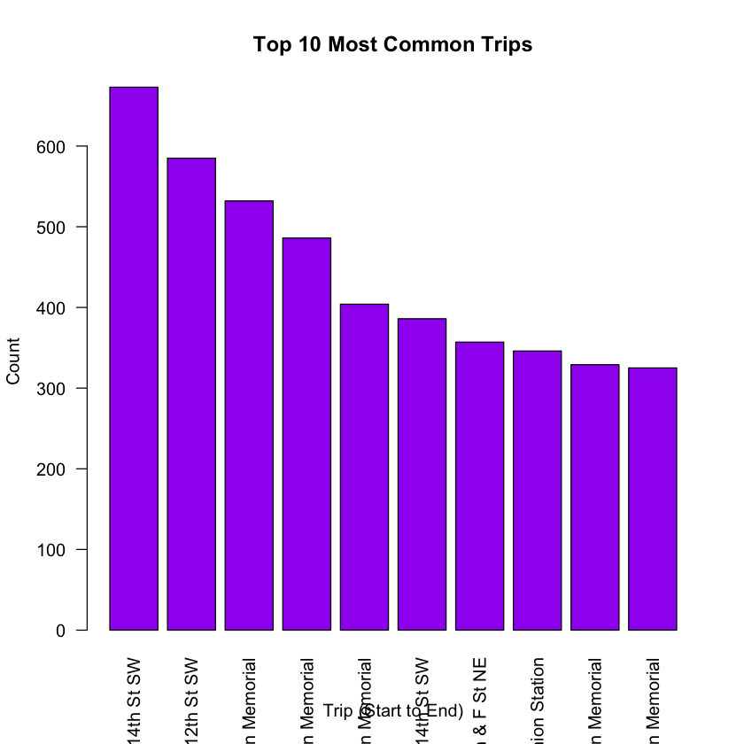

```r
#----------------------------------------
# Main Script: Loop Over Cities
#----------------------------------------
# List of cities to analyze (make sure the corresponding CSV files are in your working directory)
cities <- c("chicago", "new-york-city", "washington")

for (city in cities) {
  cat("\n============================================\n")
  cat("Analysis for:", toupper(city), "\n")
  cat("============================================\n")

  # Load the city data
  data <- load_data(city)

  #----------------------------------------
  # Explore Popular Stations and Trips
  #----------------------------------------
  cat("\n--- Popular Stations and Trips ---\n")
  popular_stations(data)

}
```

### Question 3

**Your question 3 goes here.**

What insights can we glean about trip duration?

```r
# Your solution code goes here
#----------------------------------------
# Analysis Function: Trip Duration
#----------------------------------------
trip_duration_stats <- function(data) {
  # Compute total and average trip duration (in seconds)
  total_travel_time <- sum(data$Trip.Duration, na.rm = TRUE)
  mean_travel_time  <- mean(data$Trip.Duration, na.rm = TRUE)

  cat("Total travel time (in seconds): ", total_travel_time, "\n")
  cat("Average travel time (in seconds): ", mean_travel_time, "\n")

  # Plot: Distribution of Trip Durations
  hist(data$Trip.Duration,
       breaks = 50,
       main   = "Trip Duration Distribution",
       xlab   = "Trip Duration (seconds)",
       col    = "orange",
       border = "white")
}
```

```
============================================
Analysis for: CHICAGO
============================================

--- Trip Duration Statistics ---
Total travel time (in seconds):  280871787
Average travel time (in seconds):  936.2393

============================================
Analysis for: NEW-YORK-CITY
============================================

--- Trip Duration Statistics ---
Total travel time (in seconds):  269905248
Average travel time (in seconds):  899.6842
```

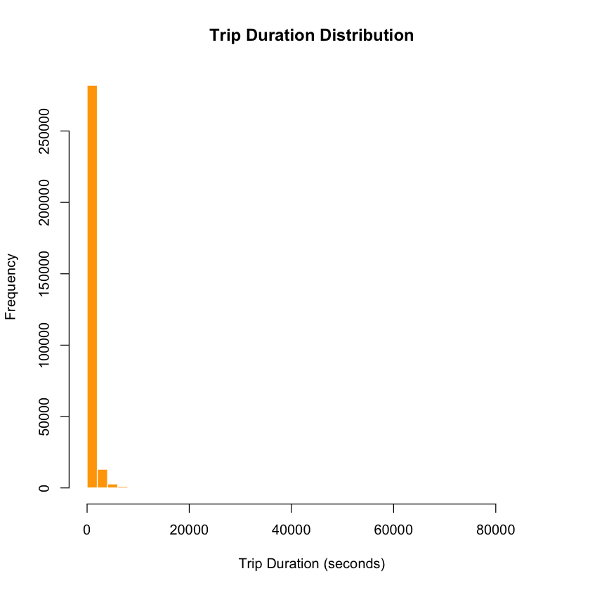

```
============================================
Analysis for: WASHINGTON
============================================

--- Trip Duration Statistics ---
Total travel time (in seconds):  371183985
Average travel time (in seconds):  1237.28
```

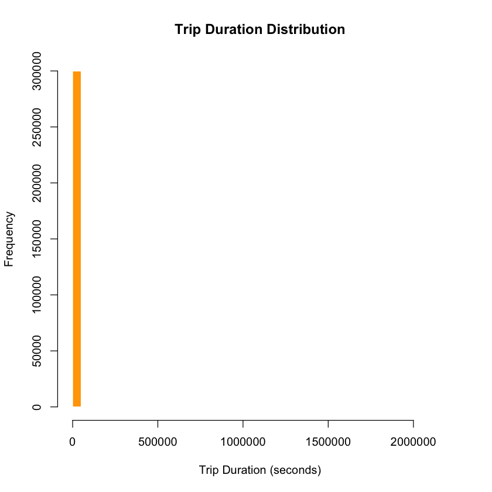

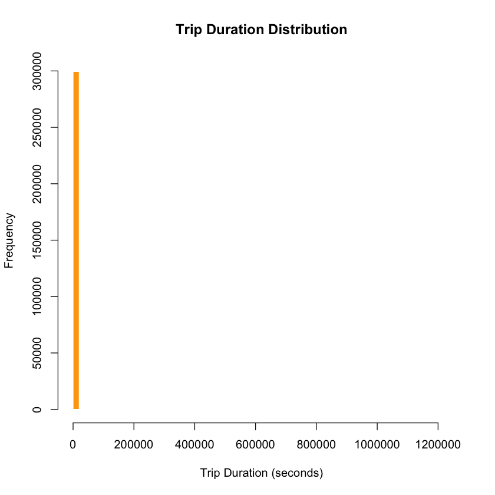

```r
#----------------------------------------
# Main Script: Loop Over Cities
#----------------------------------------
# List of cities to analyze (make sure the corresponding CSV files are in your working directory)
cities <- c("chicago", "new-york-city", "washington")

for (city in cities) {
  cat("\n============================================\n")
  cat("Analysis for:", toupper(city), "\n")
  cat("============================================\n")

  # Load the city data
  data <- load_data(city)

  #----------------------------------------
  # C. Explore Trip Duration Statistics
  #----------------------------------------
  cat("\n--- Trip Duration Statistics ---\n")
  trip_duration_stats(data)
}
```

**Summary of your question 3 results goes here.**

Average travel time right around 15 minutes for both Chicago and New York, potentially showcasing greater ability for bicycle travel within those cities, compared to Washington.

## Directions to Submit

> Before you submit your project, you need to create a .html or .pdf version of this notebook in the workspace here. To do that, run the code cell below. If it worked correctly, you should get a return code of 0, and you should see the generated .html file in the workspace directory (click on the orange Jupyter icon in the upper left).

> Alternatively, you can download this report as .html via the **File** > **Download as** submenu, and then manually upload it into the workspace directory by clicking on the orange Jupyter icon in the upper left, then using the Upload button.

> Once you've done this, you can submit your project by clicking on the "Submit Project" button in the lower right here. This will create and submit a zip file with this .ipynb doc and the .html or .pdf version you created. Congratulations!

```r
system('python -m nbconvert Explore_bikeshare_data.ipynb')
```